# Introduction à Linux et à l’environnement Conda

Septembre 2024

## Introduction à Linux et à l’environnement Conda

- **Partie 1: Linux Basique**
  - Qu’est ce que **Linux** ?
  - La ligne de commande
  - La manipulation de fichiers
- **Partie 2: Utilisation de Linux - plus avancée**
- **Partie 3: La manipulation de processus (jobs)**
- **Environnement Conda**
  - L’environnement de gestion de logiciels **Conda**
- **Utilisation d’un cluster de calcul sous *Slurm***
  - Utilisation du **cluster de l’IFB**

## Première Partie: Linux Basique

## Linux

- C’est un système d’exploitation **ouvert** et **libre**, issu du monde de la recherche.
- Cela signifie que **tout le monde** peut l’utiliser, le modifier et l’étudier.
- Vous l’utiliser probablement déjà car il est à la base d’Android et fait tourner un grand nombre de serveurs Web (67% source: W3Tech).
- **Linux** est stricto-sensu le **noyau**. Le système complet est **GNU-Linux**, souvent **distribué** avec de nombreux programmes (éditeurs, terminaux, etc..)

Il est accessible sous forme de **Distribution:** dont les deux familles **principales** sont:

- *Ubuntu*, *Mint*, *Debian*,
- *RedHat*, *CentOS*, etc…

(Voir le site http://distrowatch.com)

## Organisation

- **Multi-utilisateur:** chaque utilisateur possède un **espace propre** accessible par un **mot de passe**
- Plusieurs utilisateurs peuvent travailler en même temps sur une même machine, par la console, ou par des connections distantes
- Chaque fichier possède des **permissions** associées aux **utilisateurs**. Il est la **propriété** d’un utilisateur et il est possible, pour cet utilisateur, de choisir des permissions spécifiques

## Pourquoi ne pas utiliser Windows pour faire de la bioinformatique ?

- Linux est à code source ouvert. Il est issu de **l’industrie** et de la **recherche scientifique** et a été concu pour le **traitement** de gros corpus de données
- Linux est **multi-tâches** et **multi-utilisateurs**
- Windows est sous **licence payante**
- Linux est **scalable**, (fonctionne aussi bien qur votre PC que sur de gros serveurs multiprocesseurs) (2048 max!) avec une grosse mémoire (256To max!)
- Linux est plus **fiable** que Windows, et mieux **sécurisé (Pas de virus)**
- **Linux est très personnalisable** et il est possible d’installer uniquement les composants dont l’utilisateur a besoin
- Les programmes utilisés en bioinformatique, dont font partie **Python** et **R** ont été développés sous Linux
- Les programmes **vendus** pour Windows sont chers et sont des **boites noires** (pas de code source dispo)

## Plusieurs types de connection

Linux étant un système **multi-utilisateur**, il est capable de gérer plusieurs connections simultanément. Il est donc **nécessaire** de se **connecter au système** pour l’utiliser, ce qui lui permet de nous identifier.

- Soit sous forme de connection *Locale* sur la console graphique (ou texte)

[figure not shown]

- Soit sous forme de connection *Distante* (Secure Shell - *ssh*). Utlilisation de *Putty* ou *MobaXterm* sous *Windows*, et du programme *ssh* sous *MacOS/Linux*.

## Les environnements graphiques

Sous Linux, l’environnement graphique est très fortement customisable est est organisé de la façon suivante:

- Le gestionnaire de fenêtres: Une couche logicielle de base pour l’affichage: **XWindow** (Sans s)
- Le Bureau: plusieurs versions existent, plus ou moins complexes et gourmandes en ressources: **KDE**, **Gnome**, **XFCE**, etc…
- Dans le cadre de la formation, nous travaillerons sous **XFCE**.

[figure not shown]

## La ligne de commande: appelée également le **Shell**

**Pourquoi** une ligne de commande ?

Linux est un dérivé d’*Unix* , un système conçu dans les années 70, sur lesquels un moyen naturel de communiquer était par ligne de commande:

- C’est un moyen plus puissant que l’interface graphique
- Peu gourmand en ressources
- Défaut: il faut une phase de formation
- Le logiciel qui permet de donner des ordres au noyau est le *shell*. Un exemple de shell est Bash* (*Bourne Again Shell*).
- C’est un véritable **Langage de programmation** possédant une structure de contrôle de très grande puissance!

## Que permettent les commandes ?

Une **commande** permet de:

- **Récupérer des informations système** (Exemple: nom du serveur, date, heure utilisation du disque ou de la mémoire)
- **Faire des manipulation de fichiers basiques** (création ou suppression de répertoires, copies ou déplacement de fichiers)
- **Exécuter des traitements complexes** (Exemple: alignement de séquences en analyse bioinformatique)
- **Modifier le comportement des processus** (arrêt, interruption, reprise, modification de priorité)

## Comment interagir avec Linux ?

- Sur une machine **Linux** ou **MacOS**: Nous utilisons le logiciel *Terminal* qui permet d’accéder au **Shell**.
- Sur une machine **Windows**: Il est possible d’utiliser le logiciel *MobaXterm* pour ouvrir un terminal sur la machine.
- Sur une **machine distante**: Exemple de l’IFB, connexion par https://ondemand.cluster.france-bioinformatique.fr/

Une fois connecté par l’une de ces solutions, nous utilisons le **Bourne Again Shell** (*bash*). Il s’utilise par la saisie d’une ligne de commande, suivi par un appui sur **Entree**.

```bash
utilisateur@machine:~$
```

## Connection sur une machine Linux distante par *ssh*

```bash
ssh utilisateur@machine_distante #-ajouter X pour rediriger l'écran graphique
```

Exemple: Connexion sur le **cluster de calcul de l’IFB**: `IFB-core`

```bash
ssh utilisateur@core.cluster.france-bioinformatique.fr
```

Message apparaissant à la **première connexion seulement!**. Répondre `yes`.

```bash
The authenticity of host 'machine_distante (::1)' can't be established.
ECDSA key fingerprint is SHA256:xk24jY2GxbgKTXXavyWtQqjBZwxQUYrt0FpLbrATxW8.
Are you sure you want to continue connecting (yes/no)?
```

## Votre première commande sous Linux

Votre première commande sous Linux: `ls`

```bash
ls
```

Pour fermer une connexion distante

```bash
exit
```

## Recherche d’aide sous Linux

Recherche d’aide sur une commande spécifique: les pages de *manuel*:

```bash
man ls
```

Vous pouvez utiliser les flèches pour vous déplacer dans la page. Utilisez la touche **q** pour quitter.

Aide basique

```bash
whatis ls
```

Recherche dans les pages de manuel

```bash
apropos "list directory content"
```

Et bien sur, votre **moteur de recherche favori est votre ami**!

## Navigation dans l’arborescence avec `cd`

Chemin personnel à l’arrivée dans le système:

```bash
/home/formation (ou ~)
```

Afficher le chemin courant

```bash
pwd
```

Retour au répertoire personnel

```bash
cd
```

Naviguer dans un autre répertoire

```bash
cd /bin
```

Retour au répertoire précédent

```bash
cd -
```

Remonter d’un cran dans l’arborescence

```bash
cd .. # . est le répertoire courant
```

## Autres commandes liées à la navigation

Mémorisation du répertoire courant suivi d’un cd rep

```bash
pushd rep
```

Rappel et cd dans le répertoire mémorisé

```bash
popd
```

## Lister les fichiers avec `ls`

Lister les fichiers du répertoire courant

```bash
ls
```

Lister les fichiers avec plus d’information (taille, permissions) à l’aide de l’OPTION `-l`

```bash
ls -l
```

lister les fichiers cachés (dont le nom commence par ‘.’) à l’aide de l’OPTION `-a`

```bash
ls -a
```

## Les options dans une ligne de commande

Elles peuvent être combinées tout en étant séparées: Lister **tous** les fichiers avec **Plus d’information utile**.

```bash
ls -l -a
```

Elles peuvent également être combinées de cette manière:

```bash
ls -la
```

## Autres OPTIONS `ls`

lister les fichiers avec affichage en couleur

```bash
ls -laC
```

lister les fichiers avec tri par date

```bash
ls -lat
```

lister les fichiers avec tri par date inversé

```bash
ls -lart
```

lister les fichiers avec tri par taille (plus gros en premier)

```bash
ls -laS
```

lister les fichiers avec affichage de sa taille lisible par un humain

```bash
ls -lh
```

## Création et suppression de fichiers

Création d’un fichier vide (ou mise à jour de la date d’un fichier existant)

```bash
touch fic
```

Suppression d’un fichier

```bash
rm fic
```

Création d’un répertoire

```bash
mkdir rep
```

Suppression d’un répertoire

```bash
rm -r rep
```

## Copier et renommer un fichier ou un répertoire

Copier un ou plusieurs fichier dans un répertoire `rep`

```bash
cp fic1 rep
cp fic1 fic2 rep
```

Copier un ou plusieurs fichier dans le répertoire courant: `.`

```bash
cp fic1 .
```

Copier un répertoire. Si `rep2` existe, `rep1` est copié **dans** `rep2`

```bash
cp -r rep1 rep2
```

Renommer un fichier

```bash
mv fic1 fic2
```

Déplacer un fichier dans `rep`. Si `rep` n’existe pas, `fic` est renommé en `rep`

```bash
mv fic1 rep
```

Renommer un répertoire. Si `rep2` existe, `rep1` est déplacé **dans** `rep2`.

```bash
mv rep1 rep2
```

## Copier et renommer un fichier ou un répertoire de manière distante: `scp`

Copier un fichier d’une machine distante vers le répertoire courant:

```bash
scp  <username>@core.cluster.france-bioinformatique.fr:/shared/home/<username>/fic1  .
```

Copier un répertoire d’une machine distante vers le répertoire courant:

```bash
scp -r <username>@core.cluster.france-bioinformatique.fr:/shared/home/<username>/rep  .
```

Copier un répertoire vers une machine distante:

```bash
scp -r rep <username>@core.cluster.france-bioinformatique.fr:/shared/home/<username>/
```

## Customiser son terminal: alias

Commande alias: Création d’une “commande” *customisée*:

```bash
alias ll='ls -l'       # Affichage 'long'
alias lr='ls -lrt'     # Affichage des fichiers triés par date (plus récent à la fin)
```

Liste des alias courants:

```bash
alias
```

Quelques alias utiles à ajouter par sécurité:

```bash
cp='cp -ip' (interactive + preserve date et permissions)
rm='rm -i' (interactive)
mv='mv -i' (interactive)
```

## Nommage des fichiers

Il est préférable de choisir des noms explicites pour vos fichiers, tout en restant raisonnables sur la longueur du nom.

- **Nom absolu :** chemin de la racine `/` au fichier en suivant la liste des répertoires, les noms des répertoires sont séparés par des / (Exemple: `/usr/bin` )
- **Nom relatif :** chemin du répertoire courant au fichier en suivant la liste des répertoires, les noms des répertoires sont séparés par des / (Exemple: `bin`)
- Pas de limitation trop stricte sur la longueur (plus de 200).
- Composé de lettres (minuscules et majuscules sont différenciées), de chiffres et de caractères (`/` interdit, et `-``interdit en début de nom de fichier)
- Les accents, `*`, `$`, `?`, `>`, `&` `>` espaces, sont **acceptés mais *non recommandés***
- `.` désigne le répertoire courant, `..` désigne le répertoire parent, par exemple:

```bash
ls -l "../bin"
```

## Raccourcis utiles

Il est possible d’éviter de taper entièrement une commande: **utiliser la complétion par `TAB`**

Recherche dans les commandes: **Flèches haut** ou **Flèche bas**.

Recherche de commandes: `CTRL-R` puis taper dans le champ de recherche.

```bash
(reverse-i-search)`ls': ls -la .bash*
```

Navigation dans une commande: `CTRL-<Fleche droite>` ou `CTRL-<Fleche gauche>`

```bash
(reverse-i-search)`ls': ls -la .bash*
```

Annuler l’exécution d’une commande: `CTRL-C`

```bash
du -sh^C
```

Lister l’historique:

```bash
history 30 # 30 dernières commandes
```

## Manipulation de fichiers texte

Examen du contenu d’un fichier texte:

Copiez l’exemple dans votre réperoire courant:

```bash
cp /shared/projects/tp_formation_amu_2024_166600/data/TD_Linux/sample.vcf .
```

sample.vcf

```bash
cat sample.vcf
```

A l’envers

```bash
tac sample.vcf
```

Filtrage des lignes d’un fichier texte

```bash
grep PASS sample.vcf
```

Défilement contrôlé: `more` (mieux: `less` ;-) )

```bash
less sample.vcf
```

## Types de fichiers

| Type de fichier | Utilisation |
| --- | --- |
| ordinaire | Fichier contenant des documents ordinaires (texte, images, sons, vidéo, …) |
| répertoire | répertoire (dossier) contenant des répertoires ou des fichiers |
| lien (voir commande `ln`) | lien logique vers un fichier existant |
| bloc | fichier associé à un périphérique de stockage (clé USB, DVD, disque dur, …) |
| caractère | fichier associé à un périphérique d’entrée-sortie (clavier, écran, …) |
| socket | fichier associé à un point de connexion réseau ( échange de données) |
| tube (\|) | fichier associé à l’exécution automatique d’une commande |

## Organisation du système de fichiers sous Linux

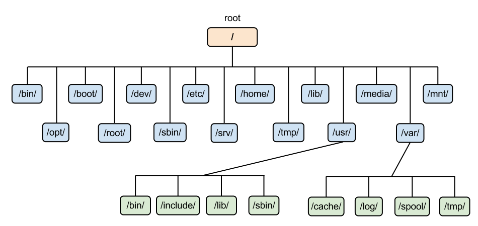

(*)

- Chemin `absolu`: `/usr/bin`
- Chemin relatif: `bin` ou `./bin` si on est déjà dans `/usr`

(*) Extrait de https://www.rs-online.com/designspark/an-intro-to-linux-file-system-management

## Quelques exemples de navigation dans l’arbrescence à l’aide de la commande `cd`

```bash
cd /bin
cd /usr/bin
cd bin
cd /
cd ..
cd ../.. # Remonter deux niveaux
cd .
cd
```

## Seconde Partie: Utilisation de Linux - plus avancée

## Commandes d’environnement

Qui suis-je ?

```bash
whoami
```

Où suis-je ?

```bash
hostname
```

Information sur votre compte

```bash
id
```

Information sur votre Système d’exploitation

```bash
uname (-a)
```

Changer votre mot de passe (**Ne le faites pas!**)

```bash
passwd
```

Qui travaille en ce moment sur le système ?

```bash
w ou who
```

## Customisation avancée

Modification du prompt: il est défini par la variable `$PS1`

```bash
echo $PS1

\[\e]0;\u@\h: \w\a\]${debian_chroot:+($debian_chroot)}\
[\033[01;32m\]\u@\h\[\033[00m\]:\[\033[01;34m\]\w\[\033[00m\]\$
```

Fichiers de configuration

```bash
.bash_profile
.bashrc
```

Ajouts de raccourcis (‘alias’) soit dans **.bash_aliases**, soit dans **.bash_profiles**

```bash
alias ll='ls -la' # Pas d'espaces autour du signe '='
```

Voir les variables d’environnement

```bash
env
```

## Métacaractères/Jokers

| Caractère | Utilisation |
| --- | --- |
| `*` | toute chaîne de caractères, potentiellement vide |
| `?` | exactement un caractère |
| `{v1,v2,v3}` | exactement un caractère, soit **v1**, soit **v2**, soit **v3** |
| `{v1..v2}` | exactement un caractère, entre **v1** à **v2** |
| `{v1..v2..v3}` | exactement un caractère, entre **v1** à **v2** par pas de **v3** |

Exemples:

```bash
echo {a..c}{1,9} {a..c}*
a1 a9 b1 b9 c1 c9 activite.png bc-lampe.jpg comparaison.py
echo {a..g..2}{1..7..2}
a1 a3 a5 a7 c1 c3 c5 c7 e1 e3 e5 e7 g1 g3 g5 g7
echo *.{jpg,png}
activite.png bc-lampe.jpg
echo {a..c}*.???
activite.png bc-lampe.jpg
```

## Affichages de caractères spéciaux

En Bash, certains caractères (`*`, `$`, `?`, `>`, `&`) jouent un rôle spécial et ne peuvent pas être affichés simplement.

```bash
echo $
$
echo $1 # paramètre positionnel 1

echo $$ # process ID du script
 20105
echo $? # statut de sortie de la dernière commande
 0
echo *
hg19_order.fa sample_19098-007.log sample_19098-007.sam fichier.gp trace.png
echo > # redirection
bash: syntax error near unexpected token ‘newline’
```

Pour les afficher, il faut les désactiver (les *échapper*) avec `\`

```bash
echo \*
```

## Organisation des droits

```bash
ls -la
total 60184
drwxr-xr-x 19 formation formation     4096 juil. 21 09:57 .
drwxr-xr-x  3 root      root          4096 mai   28 14:54 ..
-rw-------  1 formation formation      679 juil. 18 16:18 .bash_history
-rw-r--r--  1 formation formation     4018 mai   28 16:19 .bashrc
drwxr-xr-x  2 formation formation     4096 mai   28 15:24 Bureau
-rwxr-xr-x  1 formation formation 61451533 déc.  21  2020 Miniconda3-py39_
  4.9.2-Linux-x86_64.sh
```

Organisation en 3 groupes de droits

**r** = lecture

**w** = écriture

**x** = exécution

**g** = groupe

Gestion par la commande `chmod`. Exemple:

```bash
chmod u+x Miniconda3-py39_4.9.2-Linux-x86_64.sh # Executable pour l'utilisateur
```

## Commande chmod

```bash
chmod [u g o a] [+ - =] [r w x] nom_du_fichier
```

- **u** = user
- **g** = group
- **o** = other
- **a** = all

## Commande `chmod`: correspondances de représentation des droits

| Droit | Alphanumérique | Octal | Binaire |
| --- | --- | --- | --- |
| aucun droit | — | 0 | 000 |
| exécution seulement | –x | 1 | 001 |
| écriture seulement | -w- | 2 | 010 |
| écriture et exécution | -wx | 3 | 011 |
| lecture seulement | r– | 4 | 100 |
| lecture et exécution | r-x | 5 | 101 |
| lecture et écriture | rw- | 6 | 110 |
| tous les droits (lecture, écriture et exécution) | rwx | 7 | 111 |

## `chmod`: exemples

Rendre exécutable pour l’utilisateur

```bash
chmod u+x Miniconda3-py39_4.9.2-Linux-x86_64.sh
```

Rendre exécutable pour tous

```bash
chmod a+x Miniconda3-py39_4.9.2-Linux-x86_64.sh
```

Donner tous les droits à l’utilisateur, et lecture seulement pour le groupe et les autres

```bash
chmod 744 Miniconda3-py39_4.9.2-Linux-x86_64.sh
```

## Informations détaillées de `ls -la`

```bash
ls -la
total 60184
drwxr-xr-x 19 formation formation     4096 juil. 21 09:57 .
drwxr-xr-x  3 root      root          4096 mai   28 14:54 ..
-rw-------  1 formation formation      679 juil. 18 16:18 .bash_history
-rw-r--r--  1 formation formation     4018 mai   28 16:19 .bashrc
drwxr-xr-x  2 formation formation     4096 mai   28 15:24 Bureau
-rwxr-xr-x  1 formation formation 61451533 déc.  21  2020 Miniconda3-py39_
1     2    3  4         5             6    7              8
```

| Position | Caractère | Utilisation |
| --- | --- | --- |
| 1 | d | fichier ordinaire (**-**), lien logique ou symbolique (**l**), répertoire (**d**), bloc (**b**), caractère (**c**), tube (**p**), socket (**s**) |
| 2 | rw-r–r– | modalité d’accès au fichier (propriétaire, groupe et les autres). Modalités : lecture (**r**), écriture (**w**), exécution (**x**) ou pas de modalité (**-**) |
| 3 | 19 | nombre de liens (ici, lien vers un fichier existant) |
| 4 | formation | identifiant du propriétaire du fichier |

## Informations détaillées (Suite)

```bash
ls -la
total 60184
drwxr-xr-x 19 formation formation     4096 juil. 21 09:57 .
drwxr-xr-x  3 root      root          4096 mai   28 14:54 ..
-rw-------  1 formation formation      679 juil. 18 16:18 .bash_history
-rw-r--r--  1 formation formation     4018 mai   28 16:19 .bashrc
drwxr-xr-x  2 formation formation     4096 mai   28 15:24 Bureau
-rwxr-xr-x  1 formation formation 61451533 déc.  21  2020 Miniconda3-py39_
1     2    3  4         5             6    7              8
```

| Position | Caractère | Utilisation |
| --- | --- | --- |
| 5 | formation | identifiant du groupe du fichier |
| 6 | 4096 | nombre de nodes occupées par le fichier |
| 7 | juil. 21 09:57 | date de modification |
| 8 | . | nom du fichier |

## Commande `find`

Cette commande permet de trouver un fichier dans le système de fichier et éventuellement d’y appliquer une action. Sa syntaxe est la suivante:

```bash
find <répertoire> action
```

`find` fonctionne de manière récursive par défaut.

Exemples:

```bash
 # trouve tout les fichiers du répertoire courant
find . -print
# recherche le fichier .bashrc
find . -name .bashrc -print
# fichiers portant l'extension .sh
find . -name "*.sh" -print
# trouve les répertoires Images dans les répertoires utilisateurs
# et renvoie les messages d'erreurs dans /dev/null
find /home -type d -name "Images" 2> /dev/null
# recherche les fichiers portant l'extension tmp et les
# efface après confirmation;
find . -type f -name "*.tmp"  -exec rm -i  {} \;
```

## Commande `find`

Voir la page https://www.redhat.com/sysadmin/linux-find-command

`-name`: Recherche par nom de fichier.

`-type`: Recherche par type de fichier.

`-user:` Recherche par propriétaire.

`-group:` Recherche par appartenance à un groupe.

`-size:` Recherche par taille de fichier.

`-atime:` Recherche par date de dernier accès.

`-mtime` Recherche par date de dernière modification.

`-ctime`: Recherche par date de création.

`-perm`: Recherche par autorisations d’accès.

`links` : Recherche par nombre de liens au fichier

## Compression/Décompression

Il existe plusieurs commandes de **compression** et **d’aggrégation** de fichiers. Ces deux opérations sont **distinctes** sous **Linux**.

Utilitaire de compression: `gzip`

```bash
gzip fich
gunzip fich.gz
```

Plus puissant: `bzip2`

```bash
bzip2 fich
bunzip2 fich.bz2
```

## Compression/Décompression (suite)

Pour plusieurs fichiers ou un répertoire, il faut d’abord utiliser l’utilitaire d’agrégation `tar` (Tape Archiver), puis compresser.

```bash
tar cf rep.tar rep # Add -v for verbosity
gzip rep.tar
gunzip rep.tar
tar xf rap.tar     # Add -v for verbosity
```

Identique mais en combinant les opérations

```bash
tar czf rep.tar.gz rep # Add -v for verbosity
tar xzf rep.tar.gz     # Add -v for verbosity
```

Il existe également un utilitaire `zip`.

```bash
zip fic.zip fic # Compression d'un fichier
unzip fic.zip
zip -r rep.zip rep     # Compression d'un répertoire
```

## Manipulation de fichiers texte

Affichage du début d’un fichier

```bash
head fic.txt
head -10 fic.txt # affichage des 10 premières lignes
```

Affichage de la fin d’un fichier

```bash
tail fic.txt
tail -f fic.txt # avec rafraichissement
```

Extraire des colonnes d’un fichier délimité

```bash
cut  -f 2 fic.tab
cut  -f 1,3 fic.tab
cut  -f 1-3 fic.tab
cut -f 1-2,5-6 fic.tab
cut -d , -f 2 fic.csv # comma delimiter
```

## Boucles for

Il est possible d’appliquer des traitement de manière répétée par l’instruction `for`:

Un exemple simple:

```bash
for f in *txt
do
  echo "$f"
done
```

Voir: https://www.cyberciti.biz/faq/bash-for-loop/

## Editeurs interactifs sous Linux

- **Gedit**

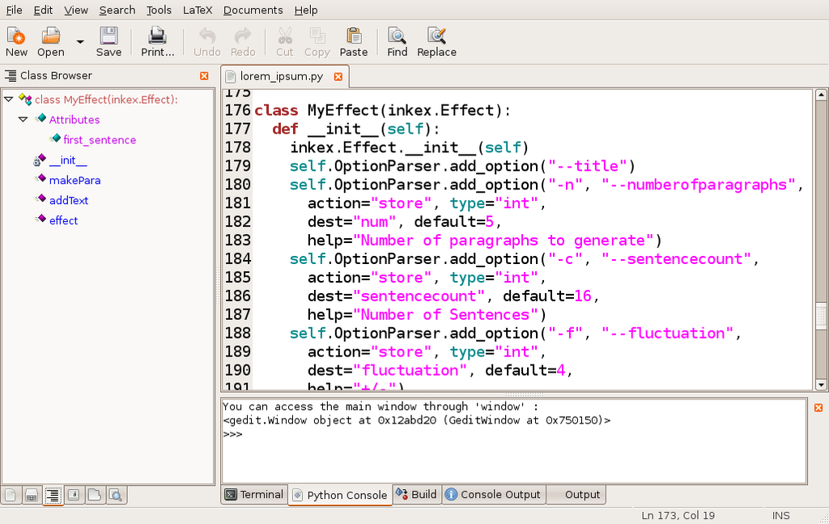

- **Nano**
- Pour administrateurs: **Vi, Emacs**

## Editeur série `sed`

`sed` est un *editeur série*. Il permets d’effectuer des manipulations de texte de manière automatisée et est particulièrement utile pour manipuler de grosses masses de données.

Exemple:

On remplace *Linus* par *Linux* dans le fichier `test.txt`

```bash
sed 's/Linus/Linux/' text.txt
```

On peut l’utiliser pour remplacer des noms de fichiers: **Exemple**: Remplacement des `-` par des `_` dans les fichiers `.txt` du répertoire courant (**Attention, c’est irréversible**).

```bash
for f in *.txt; do fn=`echo $f|sed 's/-/_/g'`; mv -i "$f" "$fn"; done
```

Un site dédié à `sed`: https://buzut.net/apprendre-commande-sed-linux/

## Téléchargement en ligne de commande

Commande `wget`

```bash
wget http://ftp.sra.ebi.ac.uk/vol1/fastq/SRR900/008/SRR9005678/SRR9005678.fastq.gz
--2021-08-04 17:08:22--  http://ftp.sra.ebi.ac.uk/vol1/fastq/SRR900
                                              /008/SRR9005678/SRR9005678.fastq.gz
Résolution de ftp.sra.ebi.ac.uk (ftp.sra.ebi.ac.uk)... 193.62.193.138
Connexion vers ftp.sra.ebi.ac.uk (ftp.sra.ebi.ac.uk)|193.62.193.138|:80...connecté.
requête HTTP transmise, en attente de la réponse...200 OK
Longueur: 1383706547 (1,3G) [application/octet-stream]
Sauvegarde en : «SRR9005678.fastq.gz»

 5% [===>
                                              ] 79 563 695  2,79MB/s  eta 7m 53s
```

## Installation de programmes sous Debian/Ubuntu

L’installation de programmes sous Linux est généralement réservé aux utilisateurs ayant les **permissions** appropriées.

Pour installez un programme dans le système, il faut être **superutilisateur** (`root`) ou bien faire partie du groupe des **sudoer**, c’est à dire avoir la permission d’utliser la commande **sudo**.

Quelques commandes utiles pour changer d’utilisateur:

```bash
su - # pour passer sur le compte root
su - <utilisateur> # pour passer sur le compte 'utilisateur'
```

L’installation se fait par un **gestionnaire de paquets**, qui gère les dépendances et les versions en fonction de la distribution utilisée.

Dans le cas de **Debian** et affiliées (**Ubuntu**, **Mint**), nous utilisons **APT**.

## Utilisation sommaire d’APT

Installation d’un programme, par exemple `gedit`:

```bash
sudo apt-get install gedit
[sudo] Mot de passe de formation :
...
Souhaitez vous continuer ? [O/n]
```

Suppression d’un paquet

```bash
sudo apt-get remove gedit # Supression d'un paquet
sudo apt-get purge gedit # Supression d'un paquet et de ses dépendances
```

## Création et exécution de scripts

**But**: Automatiser des tâches.

**Principe**: Créer un fichier texte (le *script*) contenant les instructions à exécuter.

- **Important**: Le fichier texte doit comporter le “*sha-bang*” à la première ligne:

```bash
#!/bin/bash
```

- Il doit être rendu **exécutable** par la commande `chmod`:

```bash
chmod +x monscript.sh
```

## Partie 3: Gestion des Processus

## Gestion des processus

- Un processus est un programme géré par le système. C’est autour de ce concept que sont organisés les
  - **Partage du temps CPU**,
  - **Partage de de la mémoire**
- Un processus peut avoir différents états : en **exécution**, en **sommeil**, en **sommeil sans possibilité d’interruption**, **stoppé**, **zombie** ;
- Il existe différentes **priorités d’exécution** : utilisation différenciée du temps CPU
- Processus **bloquant** (la commande associée au processus en cours bloque l’exécution de toute autre commande ultérieure):

```bash
sleep 100 ; date    # la commande date sera exécutée uniquement
                    # après les 100 secondes d’attente de la commande sleep
```

- Le système des gestion des processus est arborescent : principe parenté, duplication ; répertoire `/proc`.

## Gestion des processus (suite)

Il est important de gérer ce que l’on exécute sur la machine de manière à ne **pas la saturer** en **mémoire** ou **CPU**.

Liste des processus

```bash
ps -ef # Extended full display
```

Cherche un numéro de processus

```bash
pgrep motif
```

Utilitaire d’affichage des processus

```bash
top # ou htop
```

Affichage d’informations mémoires

```bash
pmap proc
```

Affichage de priorité

```bash
chrt -p proc
```

Lancement de cmd avec priorité 30

```bash
nice 30 cmd
```

Changement de priorité de proc à 30

```bash
renice 30 proc
```

Envoi d’un signal **-9** à proc

```bash
kill -9  proc
```

## Mode bloquant

Pour exécuter trois commandes séquentiellement:

```bash
cmd1
cmd2 # S'exécute une fois cmd1 terminée
cmd3 # s'exécute une fois cmd2 terminée
```

ou

```bash
cmd1; cmd2; cmd3
```

## Exemple

- Un alignement de séquences suivi d’une fusion (“merge”) des séquences alignées:

```bash
bwa mem -a -t 8 ref.fa reads/data_1.fastq reads/data_2.fastq > GDR-18_pe.sam
bwa mem -a -t 8 ref.fa reads/data_SE.fastq > GDR-18_se.sam
samtools merge GDR-18.sam GDR-18_pe.sam GDR-18_se.sam
```

- Les deux commandes d’alignements `bva mem` sont indépendantes et peuvent donc s’exécuter indépendamment l’une de l’autre.
- La commande `samtools` doit être exécutée **uniquement** lorsque les commandes `bva mem` sont **terminées**.

## Mode non bloquant

- Imaginons que `cmd1` et `cmd2` soient indépendantes et que `cmd3` soit dépendante du résultat de `cmd1` et `cmd2`.
- Il est possible de lancer une seconde commande sans bloquer le terminal en ajoutant une esperluette (`&`) à la fin de la première commande.

```bash
cmd1 &
cmd2
cmd3
```

## Exemple de commande lancée en mode non-bloquant

- Nous lançons les deux commandes d’alignement simultanément en ajoutant un **&** à la fin de la première commande:

```bash
bwa mem -a -t 8 ref.fa reads/data_1.fastq reads/data_2.fastq > GDR-18_pe.sam &
bwa mem -a -t 8 ref.fa reads/data_SE.fastq > GDR-18_se.sam
```

- Le terminal nous renvoie un message quand les deux commandes sont terminées:

```bash
[1]+ Done bwa mem -a -t 8 ref.fa reads/data_1.fastq...
```

- Puis on peut lancer le merge par **samtools**:

```bash
samtools merge GDR-18.sam GDR-18_pe.sam GDR-18_se.sam
```

## Contrôle des jobs

Ces commandes lancées en arrière-plan sont des **jobs**. Ils peuvent être contrôlés par les commandes suivantes:

- Affichage des jobs:

```bash
jobs
[1]+ Running bwa ... & # Cette commande tourne dans le canal 1
```

Il est possible de lancer plusieurs commandes en arrière plan simultanément dans différents *canaux*.

- Contrôle des jobs

```bash
<CTRL><C> # Terminaison d'un job (annulation)
<CTRL><Z> # Suspension d'un job
```

## Exemples d’actions de contrôle de jobs

- Utilisation de **<CTRL><C>** et **<CTRL><Z>**

```bash
gzip human_g1k_v37.fasta ^C # job annulé
gzip human_g1k_v37.fasta ^Z # job suspendu
[1]+ Stopped gzip human_g1k_v37.fasta
jobs
[1]+ Stopped gzip human_g1k_v37.fasta
```

- Commandes de contrôle `fg`, `bg` et `kill`:

```bash
kill %1 # termine le job sur le canal 1
fg %1 # passe le job  du canal 1 en mode bloquant (foreground)
bg %1 # passe le job du canal 1 en mode non-bloquant (background)
```

## Sorties standard/erreur

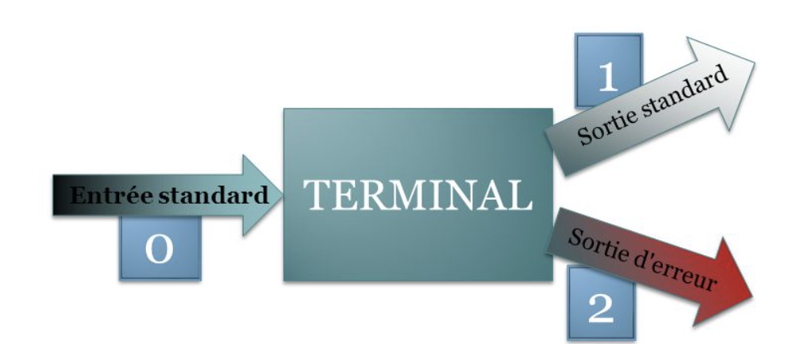

- **Entrée standard** (0) : contenu d’un fichier, clavier, flux de données
- **Sortie standard** (1): écran habituellement
- **Sortie standard des erreurs** (2): écran habituellement

Possibilité de remplacer l’entrée ou les sorties standards par un *fichier* :

- **Exemple d’utilisation:** Utilisation de données stockées dans un fichier à la place de la saisie clavier (Utile pour de gros volumes de données)
- **Exemple d’utilisation 2:** le résultat de la commande est directement stocké dans un fichier (Par exemple pour générer un fichier *log*).

## Redirection de la sortie standard (1) dans un fichier

Utilisation de `>` pour stocker la sortie dans un fichier (le fichier est **écrasé**)

```bash
grep ’Chr’ data.txt > info_Chr.txt
bwa mem -a -t 8 ref.fa reads/data_SE.fastq > GDR-18_se.sam
```

Utilisation de `>>` pour ajouter la sortie dans un fichier existant (le contenu du fichier est **conservé**)

```bash
extrait_chromosome.py chr8 data.fa > resultats2.fa
ls -s resultats2.fa
1302112 resultats2.fa
extrait_chromosome.py chr5 data.fa >> resultats2.fa
ls -s resultats2.fa
3009296 resultats2.fa
```

## Redirection de la sortie d’erreur standard (2) dans un fichier

Utilisation de `2>` pour stocker la sortie d’erreur dans un fichier (le fichier est **écrasé**)

Exemple:

```bash
$ bwa mem -t 32 -P -M human_g1k_v37.fasta
sample_19098-007_R1.fastq.gz sample_19098-007_R2.fastq.gz
> sample_19098-007.sam 2> sample_19098-007.log
```

- Le résultat de la commande `bwa mem` est stocké dans le fichier `sample 19098-007.sam`
- Les erreurs et messages d’information sont stockées dans le fichier `sample 19098-007.log`

## Autres redirections

- Redirection des erreurs standards (2) vers la sortie standard (1) avec `2>&1`

```bash
$ commande 2>&1
```

- Redirection des erreurs standards (2) vers la sortie standard (1) avec `2>&1` et redirection du tout vers un fichier `fic.log`

```bash
commande > fic.log 2>&1
```

- Redirection des erreurs standards (2) vers la sortie standard (1) avec `2>&1` et redirection du tout vers `/dev/null` (suppression)

```bash
commande  >> dev.null  2>&1
```

## Chainage de commande par tube

Utilisation du symbole tube **|** (*pipe*).

Le tube permet de rediriger la **sortie standard** de la première commande vers l’**entrée standard** de la seconde commande

Exemple: Calcul du nombre total de read dans un fichier fastq

```bash
grep '+' my.fastq | wc -l
```

## Execution de programmes en tâche de fond

Il existe des utilitaires pour exécuter des programmes en tâche de fond: Cela permet de faire tourner un programme après fermeture de la session par l’utilisateur.

- Directement en ligne de commande: `nohup`

```bash
nohup gzip human_g1k_v37.fasta &
nohup: les entrées sont ignorées et la sortie est ajoutée à « nohup.out »
```

- Plus avancé: lancement de terminaux persistants avec `screen`

```bash
screen # création d'un screen
screen -l # liste les session screen
screen -r <numero> # récuperer une session screen (attacher)
screen -d <numero> # détacher une session screen
```

## L’environnement Conda

## Environnement Conda

Conda est une **plateforme de gestionnaire de paquets et d’environnements logiciels** permettant d’installer à sa guise des dizaines de paquets Python, R et d’utilitaires Linux, incluant la **plupart des programmes** utilisés en bioinformatique.

C’est un système très utile pour **l’utilisateur débutant**, aussi bien que pour **l’utilisateur expérimenté** car il permet:

- L’installation de programmes sans **droits administrateurs** (!)
- De gérer des dépendances de paquets avancées lors des installations.

Voir le site: https://docs.conda.io/en/latest/

## Comment fonctionne Conda ?

Conda s’apppuie sur un installateur. Dans ce cours, nous utilisons **miniconda**. une version en ligne de commande simple. Il existe également **Anaconda**, une version plus complète incluant *Anaconda Navigator*, un gestionnaire conda graphique.

En plus du programme d’installation existent les **canaux** (*channels*), contenant les programmes gérés par Conda. Le canal contenant les programmes de bioinformatique s’appelle **bioconda**.

Comment installer **miniconda + bioconda** ?

- Etape 1: récupérer le programme `miniconda`:
- Etape 2: configurer les **canaux**
- Etape 3: chercher des **programmes** et les **installer**
- Etape 4: gérer ses **environnements**

## Installation

- Aller sur le site https://docs.conda.io/en/latest/miniconda.html
- Récupérer la bonne version (Linux Python 3.9)
- Exécuter l’installateur

```bash
chmod +x Miniconda3-py39_4.9.2-Linux-x86_64.sh
./Miniconda3-py39_4.9.2-Linux-x86_64.sh
```

Une fois installé, l’invite bash comporte l’entête “base”:

```bash
(base) utilisateur@machine:~ $
```

## Les canaux (Channels)

Les programmes sont accessible à travers un index contenu dans les canaux (*channels*).

Les programmes bioinformatiques ne sont pas accessibles par défaut. Ces programmes sont dans le channel *bioconda*, qu’il faut configurer.

La canal *conda-forge* contient des programmes supplémentaires apportés par la communauté de développeurs.

```bash
conda config --add channels defaults
conda config --add channels bioconda
conda config --add channels conda-forge
```

## Gérer les environnements

Plutôt que de tout installer ce dont nous avons besoin au même niveau, il est possible de compartimentaliser les programmes dont nous avons besoin dans différents **environnement** Conda pour:

- **Regrouper logiquement** les programmes dédiés à une tâche précise, par exemple, créer un environnement dédié à l’analyse RNA-Seq.
- Avoir à disposition **plusieurs versions** d’un programme.
- Gérer des environnements **plus légers**, donc plus rapides à mettre à jour et à exporter vers d’autres systèmes.
- Eviter de se retrouver avec des programmes **incompatibles** dans le même environnement.

## Commandes de gestion d’un environnement Conda

Créer un environnement

```bash
conda create -n rnaseq
```

Lister les environnements

```bash
conda env list
```

Activer un environnement

```bash
conda activate rnaseq
```

Sortir de l’environnement courant (retour dans *base*)

```bash
conda deactivate
```

## Commandes pour l’installation de programmes

Recherche un programme par nom

```bash
conda search samtools
conda search *st*
```

Installer un programme

```bash
conda install samtools
```

Installer plusieurs programmes

```bash
conda install samtools fastqc multiqc
```

Installer une version particulière d’un programme

```bash
conda install subread=2.0.1
```

## Lister

Les environnements

```bash
conda env list
```

Les programmes dans l’environnement courant

```bash
conda list
```

## Mise à jour de Conda

Nécessite un peu de patience !

```bash
conda update -n base conda
conda update --all
```

Sauver/restaurer une configuration d’environnement dans un fichier `yml``

```bash
conda env export -n envname > envname.yml
conda env create --file envname.yml
```

Aide en ligne

```bash
conda -h
```

## Utilisation d’un cluster de calcul sous *Slurm*

## Cluster de l’IFB

Pour lancer des calculs lourds, nous utilisons le **Cluster de calcul** **IFB-Core** de l’**Institut Français de Bioinformatique:** https://www.france-bioinformatique.fr/cluster-ifb-core/

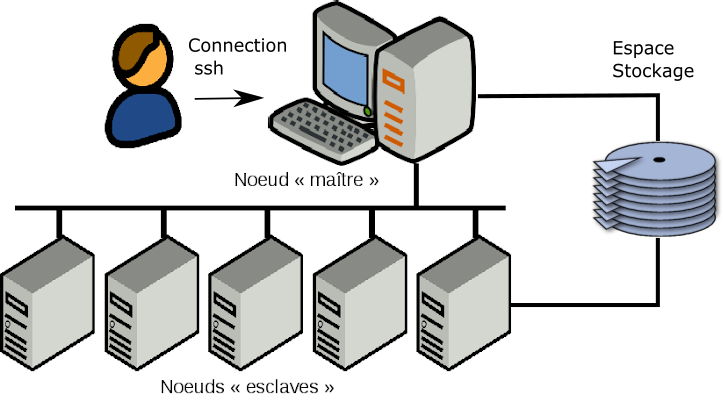

## Organisation du cluster de l’IFB

La documentation utilisateur est disponible à https://ifb-elixirfr.gitlab.io/cluster/doc/

**Le cluster de l’IFB est organisé de la manière suivante:**

- Un **nœud maître** sur lequel on se connecte directement
- Des **nœuds de calculs** qui permettent d’exécuter les *jobs*.
- Un **stockage destiné au calcul** (ce n’est **pas** un **stockage permanent**).
- Accès à travers un *ordonnanceur* (**Slurm**). Cet ordonnanceur est un système de réservation de ressources (temps, mémoire et nombre de coeurs)
- Il met les jobs **en attente** en attendant leur traitement une fois que les ressources demandées sont disponibles.

## Utilisation pratique: connection

Connection par `ssh`

```bash
ssh user@core.cluster.france-bioinformatique.fr
```

Connection par **OnDemand**

https://ondemand.cluster.france-bioinformatique.fr/

Qui donne accès à

- JupyterHub
- RStudio

## Visusalisation des jobs courants

Liste des jobs tournant sur le cluster

```bash
squeue
```

Liste des jobs de l’utilisateur *user* tournant sur le cluster

```bash
squeue -u user
```

Visualisation du job *n* tournant sur le cluster

```bash
squeue -j n
```

## Partitions

- Une partition permet de gérer les priorités des jobs:
  - Partition `fast`: Pour les **jobs de 0 à 24h** (défaut).
  - Partition `long`: Pour les **jobs de 0 à 30j** (défaut).

Pour voir la liste des partitions:

```bash
sinfo
```

Un **acompte** (appelé également **projet**) permet de faire de l’*accounting* au propriétaire du cluster et de voir quel projet consomme des ressources.

Par défaut, les jobs sont soumis au compte `démo` qui possède 6h de calcul. Dans le cadre de cette formation, nous utilisons l’acompte `form_2022_30`.

## Gestion des jobs sous Slurm

Soumission d’un job sur un acompte:

```bash
sbatch -A <acompte> ./script.sh
```

Annulation d’un job

```bash
scancel <numéro du job>
```

## Formatage d’un script pour soumission

On peut préciser les variables `SBATCH` suivantes:

```bash
#!/bin/bash

#SBATCH --job-name=trimming           # Job name
#SBATCH --mail-type=END,FAIL          # Mail events (NONE, BEGIN, END, FAIL, ALL)
#SBATCH --mail-user=<user_mail>       # Where to send mail
#SBATCH --ntasks=1                    # Run on a single core
#SBATCH --mem=5gb                     # Job memory request
#SBATCH --time=02:00:00               # Time limit hrs:min:sec
#SBATCH --output=trimming_%j.log      # Standard output and error log

for fastqgz in *.fastq.gz
do
        echo "process $fastqgz"
        trimmomatic ....
done
```

## Soumission du job

On soumet le job sur un *Acompte* (Obligatoire sinon c’est le compte `demo` qui est utilisé). Dans le cadre de la formation, l’acompte est `form_2022_30`:

```bash
sbatch -A form_2022_30 myscript.sh
```

On peut surveiller le bon déroulement d’un job par

```bash
squeue -u <username>
```

Le résultat de la soumission génère deux sorties:

- Un ou 2 fichiers texte contenant les **sorties standards** et **sorties d’erreur standards**
- Le cas échéant, l’utilisateur reçoit un e-mail (si spécifié dans les options)

## Quelques sources d’information supplémentaires:

- Présentation du système Linux: https://jplu.developpez.com
- Tutoriel de l’ENS: https://www.tuteurs.ens.fr/unix/
- *Le Système Linux* par Matt Welsh (O’Reilly)
- Merci à Laurent Mouchard (Univ. Rouen) pour son cours Linux (L3) qui m’a inspiré certaines diapositives.

## Licence

Cette œuvre est mise à disposition selon les termes de la [Licence Creative Commons:](http://creativecommons.org/licenses/by-nc-nd/4.0/)  
Attribution - Pas d’Utilisation Commerciale - Pas de Modification 4.0 International (CC BY-NC-ND 4.0).